# Machine Learning Meets Pure Mathematics

June 1, 2018

## Emergent Reducibility: Examples

- We say a polynomial has **emergent reducibility** if \(f(x)\) is irreducible, but \(f(f(x))\) is reducible.
- \(f(x) = x^2-8x+20\), then \[ f(f(x)) = (x^2-8x+20)^2-8(x^2-8x+20)+20 \] \[ \qquad = (x^2-10x+26)(x^2-6x+10) \]
- \(f(x) = x^2-x-1\) is irreducible but \(f(f(f(x)))\) factors.
- \(f_a(x) = -8ax^3-(8a+2)x^2+(4a-1)x+a\) irreducible but \(f_a(f_a(x))\) factors for positive integer \(a\).

## Why Mathematicians care?

- The roots of iterates form a tree
- The automorphism groups of the trees have a natural *Galois* structure, and are structurally similar to \(p\)-adic Lie groups

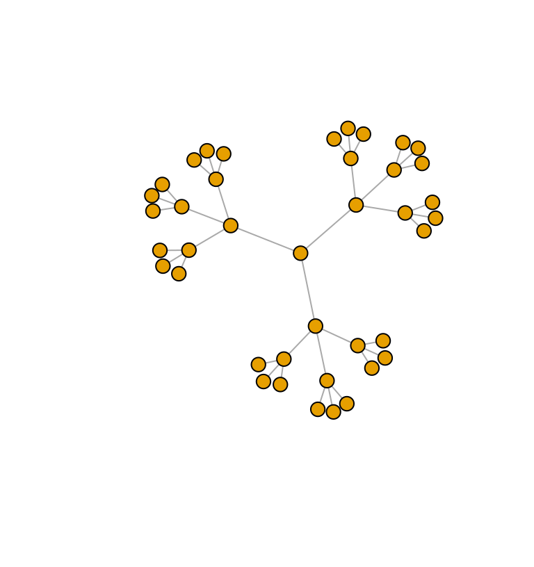

## Frequency and Imbalance

- Brute-force search of over \(200\) million irreducible cubics
- Found \(59\) examples of ER
- Typical *solution* to class imbalance: re-balance training sets
- How does re-balancing effect different models?

## Machine Learning Process

## Build Sets

- Read data in with data.table (11GB)
- Remove duplicates
- Build 21 training sets
- Each has same 43 ER cases
- Number of non-ER varies from 500 to 2500 by 100
- Non-ER cases are sampled from main dataset
- One test set, 16 ER cases and 8000 non-ER

## Build NER R code

mkNER.R:

```r
  bigNER <- fread(bigFile, header=TRUE, sep=",")
  bigNER <- bigNER[!duplicated(bigNER) & bigNER$numFact==1,]

    samps <- sapply(nerSize, function(x) sample(1:n, x,
                                            replace = FALSE))
    nerss <- map(samps, function(x) bigNER[x,])
    for(i in 1:length(nerSize)){
      trsName <- paste(paste("NERtrain",nerSize[i],
                             sep = "-"),"csv",sep=".")
      write.csv(nerss[[i]],trsName, row.names = FALSE)
    }
```

## Models

For each of the 21 training sets, we'll build 9 models

- 3 logistic regression with **regularization** (glmnet)
- 4 random forests
- naive Bayes, knn
- Each model build using 10-fold cross validation and "Kappa" error metric

## One of the models:

```r
library(caret)
library(doParallel)
  cl <- makeCluster(detectCores())
  registerDoParallel(cl)

 tr1.rfs <- train(numFact~const+lin+quad+cube+nSign+pSign+sigReal,
                  data=trs1, method="rf", metric = "Kappa",
                  trControl = trainControl(method="cv",
                              number = 10, allowParallel = TRUE))

 tst$rfs <- predict(tr1.rfs, tst, type = "prob")[,2]

 stopCluster(cl)
```

## Confusion Data Frame

Sample of Data Frame with 1134 confusion matrices!

| mdl | TN | TP | FP | FN | ner | theta |
| --- | --- | --- | --- | --- | --- | --- |
| lrs | 8000 | 0 | 0 | 16 | 2000 | 0.30 |
| rfpp | 7908 | 10 | 92 | 6 | 2500 | 0.25 |
| rfpp | 7877 | 8 | 123 | 8 | 2400 | 0.25 |
| rfs | 7986 | 10 | 14 | 6 | 2000 | 0.50 |
| knn | 7699 | 16 | 301 | 0 | 2500 | 0.20 |
| rfsq | 7850 | 14 | 150 | 2 | 1400 | 0.25 |

## ROC: Fix ner, vary \(\theta\)

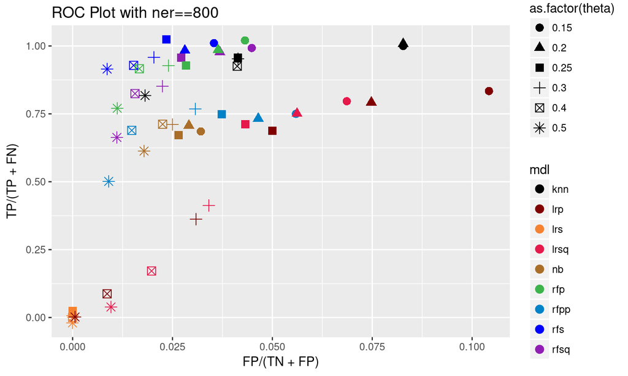

## ROC: Fix \(\theta\), vary ner

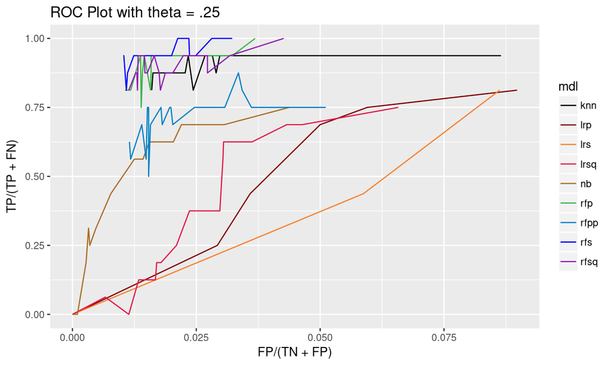

## Animated ROC

[figure not shown]

aniroc

[figure not shown]

anirocft

## Results Overview

| TP | mdl | count | avg.FP | min.ner | max.ner | max.theta |
| --- | --- | --- | --- | --- | --- | --- |
| 16 | knn | 32 | 498.1250 | 500 | 2500 | 0.20 |
| 16 | rfs | 17 | 251.0000 | 500 | 1600 | 0.30 |
| 16 | rfsq | 7 | 378.5714 | 500 | 800 | 0.25 |
| 16 | rfp | 6 | 334.8333 | 500 | 800 | 0.30 |
| 15 | rfs | 63 | 145.6825 | 500 | 2500 | 0.50 |
| 15 | rfp | 59 | 188.0169 | 600 | 2400 | 0.40 |
| 15 | rfsq | 37 | 199.2432 | 600 | 2500 | 0.30 |
| 15 | knn | 36 | 320.3056 | 500 | 1900 | 0.40 |

## Results: RF

| mdl | TN | TP | FP | FN | ner | theta |
| --- | --- | --- | --- | --- | --- | --- |
| rfs | 7830 | 16 | 170 | 0 | 1200 | 0.25 |
| rfs | 7816 | 16 | 184 | 0 | 600 | 0.30 |
| rfs | 7812 | 16 | 188 | 0 | 800 | 0.25 |
| rfs | 7799 | 16 | 201 | 0 | 1200 | 0.20 |
| rfs | 7790 | 16 | 210 | 0 | 1100 | 0.15 |
| rfs | 7781 | 16 | 219 | 0 | 500 | 0.30 |
| rfs | 7778 | 16 | 222 | 0 | 1600 | 0.15 |

## RFS Variable Importance

| variable | rfs6 | rfs8 | rfs12 |
| --- | --- | --- | --- |
| const | 100.00 | 100.00 | 98.74 |
| lin | 78.07 | 84.51 | 100.00 |
| quad | 42.50 | 43.38 | 64.10 |
| cube | 68.57 | 75.10 | 99.82 |
| sigReal | 40.78 | 33.22 | 34.99 |

## Results: KNN

| mdl | TN | TP | FP | FN | ner | theta |
| --- | --- | --- | --- | --- | --- | --- |
| knn | 7699 | 16 | 301 | 0 | 2500 | 0.15 |
| knn | 7699 | 16 | 301 | 0 | 2500 | 0.20 |
| knn | 7682 | 16 | 318 | 0 | 2100 | 0.20 |
| knn | 7681 | 16 | 319 | 0 | 2100 | 0.15 |
| knn | 7667 | 16 | 333 | 0 | 2300 | 0.15 |
| knn | 7667 | 16 | 333 | 0 | 2300 | 0.20 |
| knn | 7664 | 16 | 336 | 0 | 2000 | 0.20 |

## KNN Variable Importance

| variable | knn21 | knn23 | knn25 |
| --- | --- | --- | --- |
| const | 0.00 | 0.00 | 0.00 |
| lin | 16.19 | 16.19 | 15.94 |
| quad | 12.49 | 3.37 | 2.86 |
| cube | 12.46 | 9.49 | 8.59 |
| nSign | 28.35 | 25.41 | 25.92 |
| pSign | 28.42 | 25.17 | 25.78 |
| sigReal | 100.00 | 100.00 | 100.00 |

## Missed ER by RF

| poly | knn.mean | rfs.mean | rfp.mean | n | min.ner | max.ner |
| --- | --- | --- | --- | --- | --- | --- |
| -12,-49,94,96 | 0.400 | 0.319 | 0.141 | 2 | 2300 | 2500 |
| -14,-57,110,112 | 0.200 | 0.458 | 0.156 | 1 | 2500 | 2500 |
| 12,-49,-94,96 | 0.600 | 0.510 | 0.236 | 1 | 2300 | 2300 |
| 2,29,105,112 | 0.200 | 0.524 | 0.184 | 1 | 2300 | 2300 |
| 4,44,140,140 | 0.381 | 0.149 | 0.069 | 6 | 600 | 2500 |

## Missed ER by KNN

The following are missed by KNN

| poly | knn.mean | rfs.mean | rfp.mean | n | min.ner | max.ner |
| --- | --- | --- | --- | --- | --- | --- |
| -1,15,-56,63 | 0.20 | 0.328 | 0.492 | 1 | 2500 | 2500 |
| -14,-57,110,112 | 0.20 | 0.391 | 0.281 | 3 | 2100 | 2500 |
| 2,29,105,112 | 0.19 | 0.631 | 0.471 | 6 | 600 | 2500 |

## Properties of Misses

| poly | pSign | nSign | disc | sigReal | ht | L2ht | numFact |
| --- | --- | --- | --- | --- | --- | --- | --- |
| -14,-57,110,112 | 2 | 1 | 307396996 | 3 | 112 | 167 | 2 |
| -12,-49,94,96 | 2 | 1 | 165938692 | 3 | 96 | 143 | 2 |
| -1,15,-56,63 | 2 | 1 | -1967 | 1 | 63 | 85 | 2 |
| 2,29,105,112 | 0 | 3 | 7441 | 3 | 112 | 156 | 2 |
| 4,44,140,140 | 0 | 3 | -35840 | 1 | 140 | 202 | 2 |
| 12,-49,-94,96 | 2 | 1 | 165938692 | 3 | 96 | 143 | 2 |

## Properties of Hits

| poly | pSign | nSign | disc | sigReal | ht | L2ht | numFact | knn.mean | rfs.mean | n | min.ner | max.ner |
| --- | --- | --- | --- | --- | --- | --- | --- | --- | --- | --- | --- | --- |
| -4,-9,7,4 | 2 | 1 | 32353 | 3 | 9 | 12 | 2 | 0.933 | 0.907 | 6 | 600 | 2500 |
| -8,-17,15,8 | 2 | 1 | 513409 | 3 | 17 | 25 | 2 | 0.880 | 0.857 | 5 | 600 | 2300 |
| -2,-9,7,40 | 2 | 1 | 41273 | 3 | 40 | 41 | 2 | 0.920 | 0.867 | 5 | 600 | 2500 |
| 1,-3,-1,1 | 2 | 1 | 148 | 3 | 3 | 3 | 2 | 1.000 | 0.794 | 5 | 600 | 2300 |
| 10,-2,-6,2 | 2 | 1 | 2368 | 3 | 10 | 12 | 2 | 1.000 | 0.788 | 5 | 600 | 2300 |
| 13,23,9,1 | 0 | 3 | 148 | 3 | 23 | 27 | 2 | 1.000 | 0.779 | 4 | 600 | 2100 |
| 22,-45,-43,22 | 2 | 1 | 29292649 | 3 | 45 | 69 | 2 | 0.950 | 0.800 | 4 | 600 | 2500 |
| 24,-97,-190,192 | 2 | 1 | 2654410756 | 3 | 192 | 288 | 2 | 0.450 | 0.963 | 4 | 1200 | 2500 |

## Next

- Incorporate classifiers into search code
- Interpret RFS in detail
- See http://jpreszler.rbind.io for cubic family paper and related work.